# GLMs for Car Insurance Pricing: Combined Data Exploration

### 5.3.3 claim_count by region

We want to see if there is much of a geographical influence on claim counts in general, so we plot these separately also.

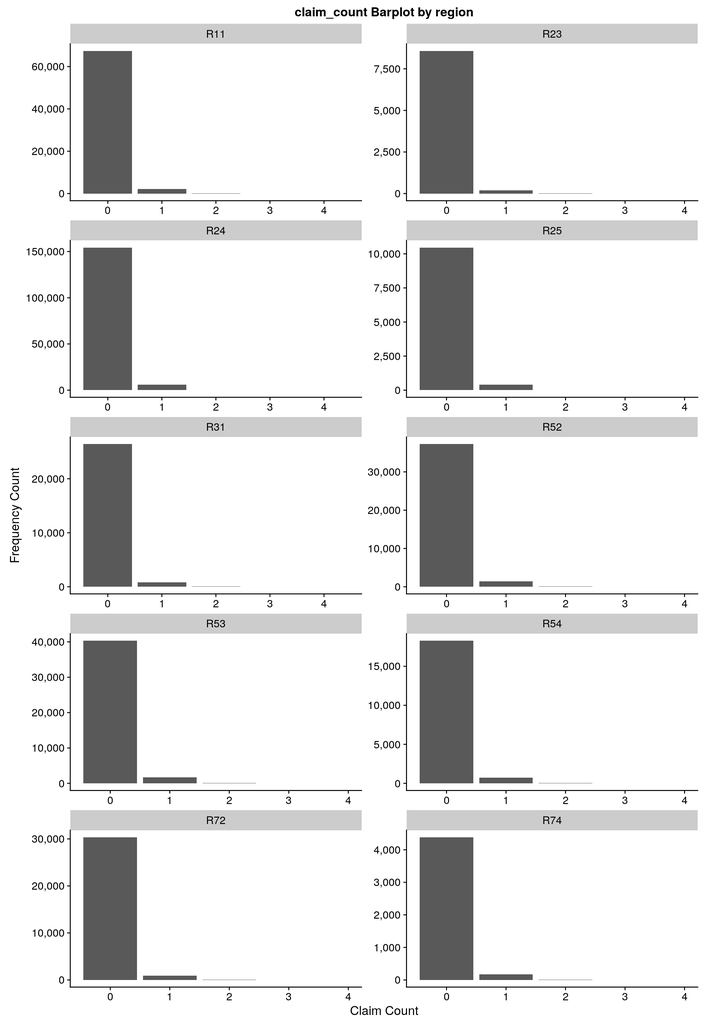

```r
ggplot(data_tbl) +
    geom_bar(aes(x = claim_count)) +
    facet_wrap(~region, scales = 'free', ncol = 2) +
    expand_limits(x = 4) +
    scale_y_continuous(labels = comma) +
    xlab("Claim Count") +
    ylab("Frequency Count") +
    ggtitle("claim_count Barplot by region")
```

We want to standardise these counts as not all regions will be equal, so we will look at this as a proportion of total policies and total exposures. The previous exploration suggests this will have little effect, but it is better to be sure as it is very quick to do.

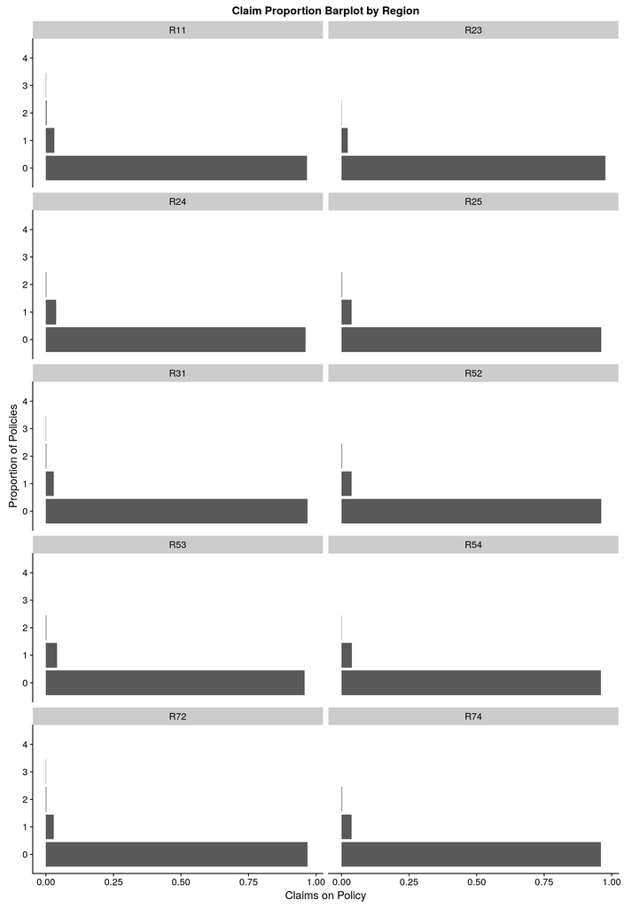

```r
policy_region_tbl <- data_tbl %>%
    count(region)

policyprop_tbl <- data_tbl %>%
    left_join(policy_region_tbl, by = 'region') %>%
    group_by(region, claim_count) %>%
    summarise(count = n()
             ,prop  = count / max(n)
              )


ggplot(policyprop_tbl) +
    geom_col(aes(x = claim_count, y = prop)) +
    facet_wrap(~region, ncol = 2) +
    coord_flip() +
    xlab("Proportion of Policies") +
    ylab("Claims on Policy") +
    ggtitle("Claim Proportion Barplot by Region")
```

We filter out the policies with no claims and re-plot.

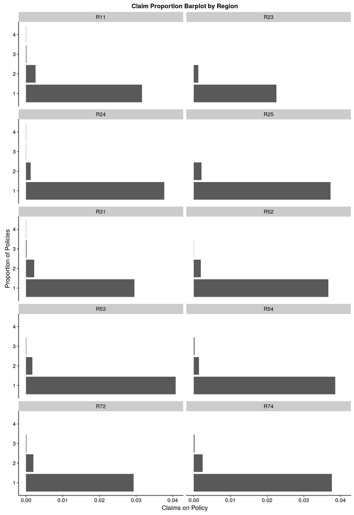

```r
ggplot(policyprop_tbl %>% filter(claim_count > 0)) +
    geom_col(aes(x = claim_count, y = prop)) +
    facet_wrap(~region, ncol = 2) +
    coord_flip() +
    xlab("Proportion of Policies") +
    ylab("Claims on Policy") +
    ggtitle("Claim Proportion Barplot by Region")
```

Looking at this a different way, we will produce the barplots by region, and facet by claim_count.

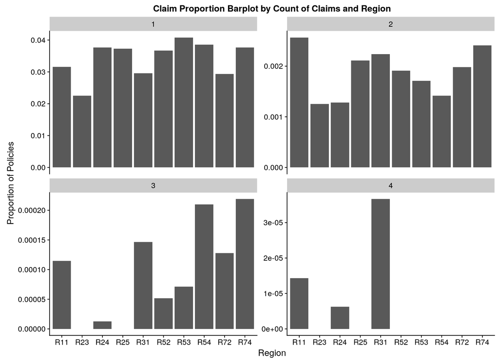

```r
ggplot(policyprop_tbl %>% filter(claim_count > 0)) +
    geom_col(aes(x = region, y = prop)) +
    facet_wrap(~claim_count, ncol = 2, scales = 'free_y') +
    xlab("Region") +
    ylab("Proportion of Policies") +
    ggtitle("Claim Proportion Barplot by Count of Claims and Region")
```

### 5.3.4 region by car_age

While unlikely, it is possible there is a geospatial distribution of car ages, so we construct a plot to look at that.

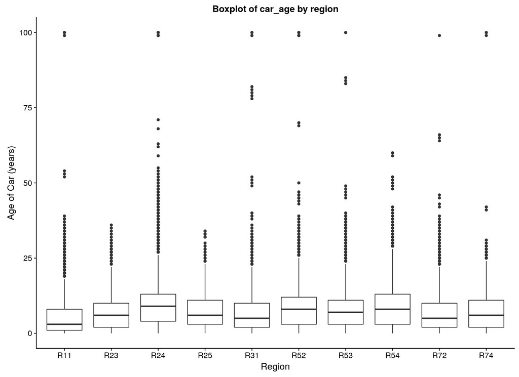

```r
ggplot(data_tbl) +
    geom_boxplot(aes(x = region, y = car_age)) +
    xlab("Region") +
    ylab("Age of Car (years)") +
    ggtitle("Boxplot of car_age by region")
```

A number of these cars are exceptionally old and are likely vintage. We may need to model these cars separately.

### 5.3.5 claim_total by region

We want to take a look at total claims paid by region to see if there is a geospatial effect for claims paid out.

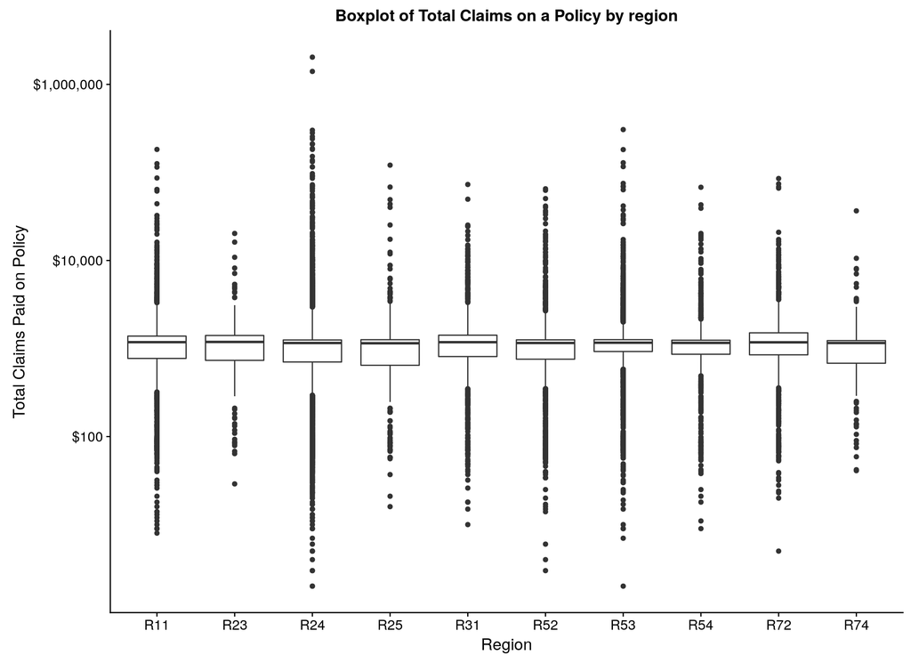

```r
ggplot(data_tbl %>% filter(claim_total > 0)) +
    geom_boxplot(aes(x = region, y = claim_total)) +
    scale_y_log10(labels = scales::dollar) +
    xlab("Region") +
    ylab("Total Claims Paid on Policy") +
    ggtitle("Boxplot of Total Claims on a Policy by region")
```

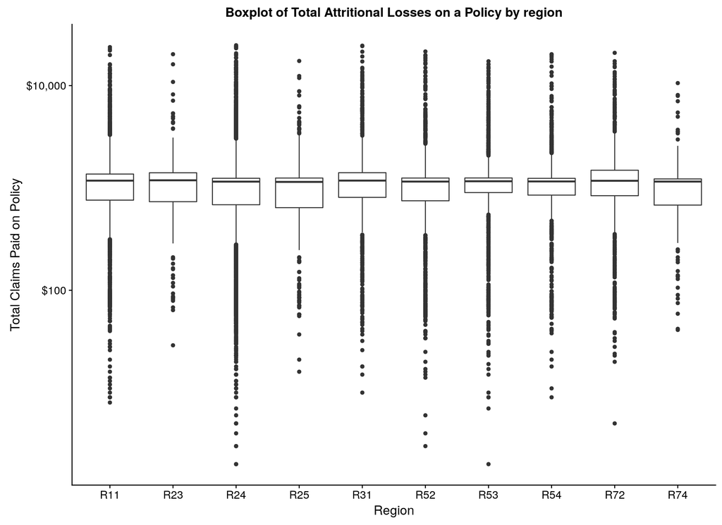

```r
ggplot(data_tbl %>% filter(claim_total <= 25000)) +
    geom_boxplot(aes(x = region, y = claim_total)) +
    scale_y_log10(labels = scales::dollar) +
    xlab("Region") +
    ylab("Total Claims Paid on Policy") +
    ggtitle("Boxplot of Total Attritional Losses on a Policy by region")
```